# Exercício aula 08 resolução detalhamento veículos

# 4. Existe diferença de emissão CO2 nos carros tipo SUV-Small das marcas KIA, SUBARU e TOYOTA?

```
##
##  Shapiro-Wilk normality test
##
## data:  data_co2$CO2.Emissions.g.km.
## W = 0.98803, p-value = 0.1967
```

**Interpretação:** Avaliando os dados de emissão de CO2 dos veículos do tipo *SUV - SMALL* das marcas *KIA*, *SUBARU* e *TOYOTA*, verificamos uma distribuição **normal** dos dados, levando em consideração o uso do método **Anova one-way** para a resolução do problema.

```
## Levene's Test for Homogeneity of Variance (center = median)
##        Df F value   Pr(>F)
## group   2  6.9764 0.001256 **
##       155
## ---
## Signif. codes:  0 '***' 0.001 '**' 0.01 '*' 0.05 '.' 0.1 ' ' 1
```

**Interpretação:** Um p-valor menor que 0.05 indica que há evidências estatísticas significativas para rejeitar a hipótese nula de que as variâncias entre os grupos são iguais. Neste caso, com um p-valor de 0.001256, que é significativamente menor que 0.05, rejeitamos a hipótese nula. Isso indica que há uma diferença estatisticamente significativa nas variâncias entre os grupos. Devido a esse levantamento, percebemos que não podemos usar o método **Anova one-way** para a resolução do problema. O método mais indicado para a resolução do problema é o **Teste de Kruskal-Wallis (ANOVA não paramétrica)**

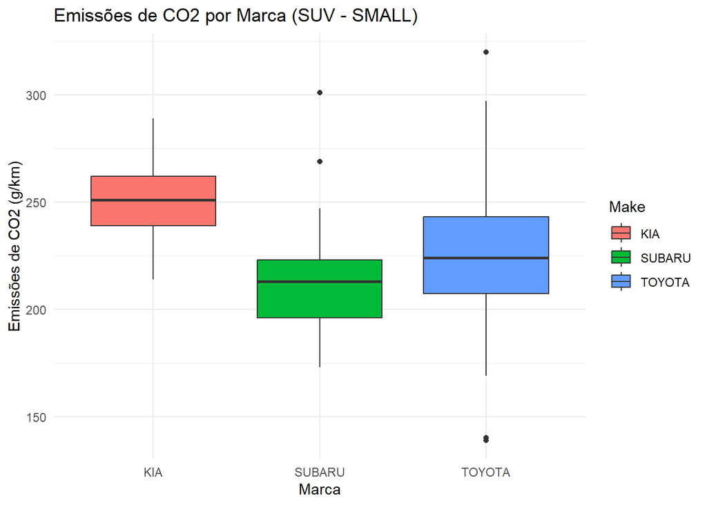

**Interpretação:**Gráfico de boxplot comparando os valores de emissão de CO2 dos dos veículos do tipo *SUV - SMALL* das marcas *KIA*, *SUBARU* e *TOYOTA*. Aparentemente há diferenças de emissão de CO2 entre os fabricantes.

```
##
##  Kruskal-Wallis rank sum test
##
## data:  CO2.Emissions.g.km. by Make
## Kruskal-Wallis chi-squared = 54.63, df = 2, p-value = 1.372e-12
```

**Interpretação:** O teste de **kruskal** testa a hipótese H0 que as medinas de emissão de CO2 dos carros do tipo *SUV - SMALL* dos fabricantes em questão são iguais. Com o valor **p-value 1.372e-12** rejeitamos a hipótese H0. Desta forma verificamos que a média de emissão de CO2 entre os veículos do tipo *SUV - SMALL* das marcas *KIA*, *SUBARU* e *TOYOTA* são diferentes.

```
##   Kruskal-Wallis rank sum test
##
## data: x and group
## Kruskal-Wallis chi-squared = 54.63, df = 2, p-value = 0
##
##
##                            Comparison of x by group
##                                  (Bonferroni)
## Col Mean-|
## Row Mean |        KIA     SUBARU
## ---------+----------------------
##   SUBARU |   7.246679
##          |    0.0000*
##   TOYOTA |   4.867700  -2.344388
##          |    0.0000*     0.0286
##
## alpha = 0.05
## Reject Ho if p <= alpha/2
```

## Interpretação do Resultado do Teste de Comparações Múltiplas

### Comparação de x por grupo (Bonferroni)

#### Comparação SUBARU vs KIA:

- **Valor p: 0.0000*** (significativo)
  - O valor p é 0.0000, indicando que essa diferença é estatisticamente significativa ao nível de significância de 0.05.

#### Comparação TOYOTA vs KIA:

- **Valor p: 0.0000*** (significativo)
  - O valor p é 0.0000, indicando que essa diferença é estatisticamente significativa ao nível de significância de 0.05.

#### Comparação TOYOTA vs SUBARU:

- **Valor p: 0.0286** (não significativo após ajuste de Bonferroni)
  - O valor p é 0.0286, que é menor que 0.05, mas maior que o nível ajustado de 0.025 (0.05/2), então não é considerado estatisticamente significativo após o ajuste de Bonferroni.

### Resumo

- O teste de Kruskal-Wallis mostra que há uma diferença significativa nas medianas dos grupos.
- As comparações múltiplas indicam que KIA tem diferenças significativas tanto com SUBARU quanto com TOYOTA.
- A diferença entre TOYOTA e SUBARU não é significativa após o ajuste de Bonferroni.

### Conclusão

Rejeitamos a hipótese nula (H0) de que todas as medianas dos grupos são iguais, e concluímos que existem diferenças significativas entre alguns dos grupos. Especificamente, KIA difere significativamente de SUBARU e TOYOTA, enquanto TOYOTA e SUBARU não diferem significativamente entre si após o ajuste de Bonferroni.